# Descriptive Analysis

European Social Survey, 2014 and 2023

Loading the necessary packages

```r
library(dplyr) #Data manipulation: filtering, grouping, mutating, and summarising
library(tidyr) #Data reshaping: pivoting data between long and wide formats
library(purrr) #Functional programming: applying the same process across multiple variables
library(rlang) #Tidy evaluation: referring to variable names programmatically inside functions
library(readr) #Data import/export: reading and writing rectangular data files
library(srvyr) #Survey analysis: creating survey-weighted designs and calculating weighted statistics
library(gt)    #produce polished publication-style tables.
library(ggplot2) # Data visualisation
library(tidytext) # Reordering labels within facets in ggplot figures
library(grid) # Grid graphics utilities, e.g., controlling legend key sizes with unit()
```

Loading the cleaned data set

This chunk loads the cleaned dataset created in the data-cleaning R Markdown file.

```r
ess_clean <- readRDS("ess_clean.rds")
```

## Inspect Cleaned Data

This chunk previews the cleaned dataset and lists all variable names. It is useful for checking that the uploaded data loaded correctly before running the descriptive analysis.

```r
names(ess_clean)
```

```
##  [1] "survey_year"          "cntry"                "country_name"
##  [4] "agea"                 "age_group"            "sex"
##  [7] "marital"              "education"            "eduyrs"
## [10] "income_group"         "income_decile"        "income_feeling"
## [13] "employment"           "occupation"           "current_smoking"
## [16] "ever_smoking"         "daily_smoker"         "daily_10plus_smoker"
## [19] "anweight"             "income_group_missing" "cgtsmke"
## [22] "cgtsday"              "cgtsmok"              "eisced"
## [25] "hinctnta"             "hincfel"              "mnactic"
## [28] "isco08"               "maritalb"             "gndr"
```

## Create Weighted Survey Design

This chunk checks for Weight availability to make sure anweight is present, positive, and not missing.

```r
ess_clean %>%
  summarise(
    n_total = n(),
    missing_weight = sum(is.na(anweight)),
    zero_or_negative_weight = sum(anweight <= 0, na.rm = TRUE),
    min_weight = min(anweight, na.rm = TRUE),
    max_weight = max(anweight, na.rm = TRUE)
  )
```

```
## # A tibble: 1 × 5
##   n_total missing_weight zero_or_negative_weight min_weight max_weight
##     <int>          <int>                   <int>      <dbl>      <dbl>
## 1   53688              0                       0    0.00319       13.0
```

check for the Final country-year sample size to see if each country has enough respondents in both waves.

```r
ess_clean %>%
  count(country_name, survey_year, name = "n") %>%
  arrange(country_name, survey_year)
```

```
## # A tibble: 34 × 3
##    country_name survey_year     n
##    <chr>        <fct>       <int>
##  1 Austria      2014         1628
##  2 Austria      2023         2221
##  3 Belgium      2014         1483
##  4 Belgium      2023         1365
##  5 Finland      2014         1861
##  6 Finland      2023         1423
##  7 France       2014         1711
##  8 France       2023         1542
##  9 Germany      2014         2691
## 10 Germany      2023         2143
## # ℹ 24 more rows
```

This chunk creates a survey design object using the ESS analysis weight, `anweight`, so that descriptive statistics account for survey weighting. The binary smoking variables are also relabelled here so that the descriptive tables display readable categories such as “Yes” and “No” instead of numeric codes.

```r
ess_survey <- ess_clean %>%
  mutate(

    current_smoking = factor(current_smoking, c(0, 1), c("No", "Yes")),
    ever_smoking    = factor(ever_smoking, c(0, 1), c("No", "Yes")),
    daily_smoker = factor(daily_smoker, c(0, 1), c("No", "Yes")),
    daily_10plus_smoker = factor(daily_10plus_smoker, c(0, 1), c("No", "Yes"))

  ) %>%
  as_survey_design(weights = anweight)
```

## Weighted Survey Year Summary

This chunk summarises the distribution of respondents by survey year. The count is unweighted, while the percentage is weighted using the ESS analysis weight, `anweight`.

```r
survey_year_summary <- ess_survey %>%
  group_by(survey_year) %>%
  summarise(
    unweighted_n = unweighted(dplyr::n()),
    weighted_n = survey_total(vartype = NULL),
    weighted_pct = survey_mean(vartype = NULL, na.rm = TRUE) * 100,
    .groups = "drop"
  ) %>%
  mutate(survey_year = as.character(survey_year))

survey_year_summary %>%
  gt(rowname_col = "survey_year") %>%
  tab_header(
    title = md("**Weighted Distribution by Survey Year**"),
    #subtitle = md("*European Social Survey, waves 2014 and 2023, 19 common countries*")
  ) %>%
  cols_label(
    unweighted_n = "Unweighted n",
    weighted_n = "Weighted N",
    weighted_pct = "Weighted %"
  ) %>%
  fmt_number(columns = c(unweighted_n, weighted_n), decimals = 0, use_seps = TRUE) %>%
  fmt_number(columns = weighted_pct, decimals = 1) %>%
  cols_align(align = "right", columns = where(is.numeric)) %>%
  tab_stubhead(label = md("**Survey year**")) %>%
  tab_options(
    table.width = pct(100),
    table.font.size = px(13),
    heading.title.font.size = px(16),
    column_labels.font.weight = "bold",
    data_row.padding = px(3),
    table.border.top.style = "solid",
    table.border.bottom.style = "solid"
  ) %>%
  tab_source_note(
    md("*Unweighted n is the observed sample size. Weighted N and weighted % use `anweight`.*")
  )
```

**Weighted Distribution by Survey Year**

| **Survey year** | Unweighted n | Weighted N | Weighted % |
| --- | --- | --- | --- |
| 2014 | 28,227 | 28,375 | 49.2 |
| 2023 | 25,461 | 29,244 | 50.8 |

*Unweighted n is the observed sample size. Weighted N and weighted % use `anweight`.*

## Select Categorical Variabless

This chunk defines the categorical variables to be described in the weighted frequency table. The names on the left are the variable names in the dataset, while the labels on the right are the names that will appear in the final table.

```r
freq_vars <- c(
  daily_smoker = "Daily smoking (primary outcome)",
  current_smoking = "Current smoking status",
  ever_smoking = "Ever smoked",
  daily_10plus_smoker = "Daily smoking 10+ cigarettes",
  education = "Education level",
  income_group_missing = "Household income (missing retained)",
  income_feeling = "Subjective income feeling",
  employment = "Employment status",
  occupation = "Occupational class",
  sex = "Sex",
  marital = "Marital status",
  age_group = "Age group",
  survey_year = "Survey wave"
)
```

## Define Categorical Summary Function

This helper function calculates unweighted counts and survey-weighted percentages for each categorical variable, either overall or by survey year.

```r
summarise_category <- function(design, variable, label, by_year = FALSE) {
  grouping_vars <- if (by_year) {
    syms(c("survey_year", variable))
  } else {
    syms(variable)
  }

  design %>%
    group_by(!!!grouping_vars) %>%
    summarise(
      n = unweighted(n()),
      pct = survey_mean(vartype = NULL, na.rm = TRUE) * 100,
      .groups = "drop"
    ) %>%
    rename(Category = !!sym(variable)) %>%
    mutate(
      Variable = label,
      Category = as.character(Category),
      survey_year = if (by_year) as.character(survey_year) else "Overall",
      .before = 1
    )
}
```

## Create Weighted Categorical Table

This chunk creates the weighted categorical descriptive table. Missing categories are removed except for household income, where missing income is retained as a real category.

```r
freq_vars_combined <- freq_vars[names(freq_vars) != "survey_year"]

weighted_frequency_combined <- imap_dfr(
  freq_vars_combined,
  \(label, var_name) {
    bind_rows(
      summarise_category(ess_survey, var_name, label, by_year = FALSE),
      summarise_category(ess_survey, var_name, label, by_year = TRUE)
    )
  }
) %>%
  filter(
    !is.na(survey_year),
    !is.na(Category),
    Category != "NA"
  )

weighted_frequency_combined_wide <- weighted_frequency_combined %>%
  pivot_wider(
    id_cols = c(Variable, Category),
    names_from = survey_year,
    values_from = c(n, pct),
    names_glue = "{survey_year}_{.value}"
  ) %>%
  select(
    Variable, Category,
    Overall_n, Overall_pct,
    matches("^2014"),
    matches("^2023")
  )

weighted_frequency_combined_wide %>%
  gt(groupname_col = "Variable", rowname_col = "Category") %>%
  tab_header(
    title = md("**Table 1. Weighted Sample Characteristics: Overall and by Wave**"),
    subtitle = md("*European Social Survey, waves 2014 and 2023, 19 common countries*")
  ) %>%
  tab_spanner(label = "Overall", columns = starts_with("Overall")) %>%
  tab_spanner(label = "2014", columns = starts_with("2014")) %>%
  tab_spanner(label = "2023", columns = starts_with("2023")) %>%
  cols_label(
    Overall_n = "n",
    Overall_pct = "%",
    `2014_n` = "n",
    `2014_pct` = "%",
    `2023_n` = "n",
    `2023_pct` = "%"
  ) %>%
  fmt_number(columns = ends_with("_n"), decimals = 0, use_seps = TRUE) %>%
  fmt_number(columns = ends_with("_pct"), decimals = 1) %>%
  sub_missing(missing_text = "—") %>%
  cols_align(align = "right", columns = where(is.numeric)) %>%
  tab_options(
    table.width = pct(100),
    row_group.font.weight = "bold",
    table.font.size = px(13),
    heading.title.font.size = px(16),
    column_labels.font.weight = "bold",
    data_row.padding = px(3),
    table.border.top.style = "solid",
    table.border.bottom.style = "solid"
  ) %>%
  tab_source_note(
    md("*Percentages are survey-weighted using `anweight`; counts are unweighted. Missing values excluded.*")
  )
```

**Table 1. Weighted Sample Characteristics: Overall and by Wave**

|  | Overall n | Overall % | 2014 n | 2014 % | 2023 n | 2023 % |
| --- | --- | --- | --- | --- | --- | --- |
| Daily smoking (primary outcome) |  |  |  |  |  |  |
| No | 43,553 | 79.7 | 22,416 | 77.6 | 21,137 | 81.7 |
| Yes | 10,063 | 20.2 | 5,775 | 22.3 | 4,288 | 18.2 |
| Current smoking status |  |  |  |  |  |  |
| No | 41,828 | 76.5 | 21,533 | 74.5 | 20,295 | 78.4 |
| Yes | 11,788 | 23.4 | 6,658 | 25.5 | 5,130 | 21.5 |
| Ever smoked |  |  |  |  |  |  |
| No | 23,156 | 41.8 | 11,854 | 40.4 | 11,302 | 43.1 |
| Yes | 30,460 | 58.1 | 16,337 | 59.5 | 14,123 | 56.8 |
| Daily smoking 10+ cigarettes |  |  |  |  |  |  |
| No | 46,094 | 85.2 | 23,557 | 82.5 | 22,537 | 87.8 |
| Yes | 7,522 | 14.7 | 4,634 | 17.4 | 2,888 | 12.1 |
| Education level |  |  |  |  |  |  |
| Low | 12,966 | 28.6 | 7,849 | 31.6 | 5,117 | 25.8 |
| Medium | 18,000 | 31.8 | 9,374 | 32.7 | 8,626 | 30.9 |
| High | 22,401 | 38.8 | 10,832 | 35.1 | 11,569 | 42.4 |
| Household income (missing retained) |  |  |  |  |  |  |
| Low | 13,491 | 23.6 | 7,624 | 25.2 | 5,867 | 22.0 |
| Middle | 19,961 | 36.8 | 10,399 | 36.8 | 9,562 | 36.8 |
| High | 13,075 | 25.7 | 6,597 | 25.2 | 6,478 | 26.2 |
| Missing income | 7,161 | 13.9 | 3,607 | 12.9 | 3,554 | 15.0 |
| Subjective income feeling |  |  |  |  |  |  |
| Living comfortably | 19,115 | 35.5 | 9,128 | 31.7 | 9,987 | 39.1 |
| Coping | 24,642 | 47.1 | 13,165 | 48.5 | 11,477 | 45.7 |
| Difficult / very difficult | 9,653 | 17.0 | 5,797 | 19.5 | 3,856 | 14.6 |
| Employment status |  |  |  |  |  |  |
| Employed | 28,790 | 54.9 | 14,782 | 53.6 | 14,008 | 56.3 |
| Unemployed | 2,305 | 4.7 | 1,504 | 5.8 | 801 | 3.5 |
| Retired | 16,100 | 27.5 | 8,231 | 26.5 | 7,869 | 28.4 |
| Inactive (other) | 6,347 | 12.7 | 3,631 | 13.9 | 2,716 | 11.5 |
| Occupational class |  |  |  |  |  |  |
| Non-manual (higher) | 22,994 | 42.1 | 11,283 | 38.8 | 11,711 | 45.3 |
| Non-manual (lower) | 12,476 | 23.6 | 6,731 | 24.4 | 5,745 | 22.8 |
| Manual | 15,636 | 29.4 | 8,820 | 31.8 | 6,816 | 27.0 |
| Sex |  |  |  |  |  |  |
| Male | 25,110 | 48.1 | 13,230 | 48.0 | 11,880 | 48.1 |
| Female | 28,578 | 51.9 | 14,997 | 52.0 | 13,581 | 51.9 |
| Marital status |  |  |  |  |  |  |
| Married/Civil union | 29,806 | 59.4 | 15,834 | 61.1 | 13,972 | 57.7 |
| Never married | 12,075 | 22.7 | 6,053 | 20.9 | 6,022 | 24.5 |
| Separated/Divorced | 6,387 | 9.8 | 3,333 | 9.6 | 3,054 | 10.0 |
| Widowed | 5,068 | 7.6 | 2,791 | 7.8 | 2,277 | 7.3 |
| Age group |  |  |  |  |  |  |
| 25-29 | 3,698 | 8.0 | 2,067 | 8.3 | 1,631 | 7.8 |
| 30-39 | 8,698 | 18.0 | 4,759 | 18.7 | 3,939 | 17.3 |
| 40-49 | 9,728 | 18.8 | 5,224 | 19.7 | 4,504 | 18.1 |
| 50-59 | 10,462 | 19.0 | 5,594 | 19.7 | 4,868 | 18.4 |
| 60-69 | 10,314 | 17.8 | 5,361 | 16.9 | 4,953 | 18.6 |
| 70+ | 10,788 | 18.3 | 5,222 | 16.8 | 5,566 | 19.8 |

*Percentages are survey-weighted using `anweight`; counts are unweighted. Missing values excluded.*

## Define Age Summary Function

This helper function calculates descriptive statistics for age. The mean, standard deviation, and median are survey-weighted, while the minimum, maximum, and sample size are unweighted.

```r
summarise_age <- function(data) {
  data %>%
    filter(!is.na(agea)) %>%
    summarise(
      Mean = survey_mean(agea, vartype = NULL),
      SD = sqrt(survey_var(agea, vartype = NULL)),
      Median = survey_median(agea, vartype = NULL),
      Q1 = as.numeric(survey_quantile(agea, quantiles = 0.25, vartype = NULL)),
      Q3 = as.numeric(survey_quantile(agea, quantiles = 0.75, vartype = NULL)),
      Min = unweighted(min(agea)),
      Max = unweighted(max(agea)),
      n = unweighted(dplyr::n())
    ) %>%
    mutate(IQR = Q3 - Q1)
}
```

## Create Weighted Age Table

This chunk calculates age descriptives overall and separately by survey wave. The results are combined into one table and formatted for presentation using `gt`.

```r
age_summary_by_wave <- ess_survey %>%
  group_by(survey_year) %>%
  summarise_age() %>%
  mutate(survey_year = as.character(survey_year))

age_summary_overall <- ess_survey %>%
  summarise_age() %>%
  mutate(survey_year = "Overall", .before = 1)

age_summary <- bind_rows(age_summary_by_wave, age_summary_overall) %>%
  select(survey_year, n, Mean, SD, Median, Q1, Q3, IQR, Min, Max)

age_summary %>%
  gt(rowname_col = "survey_year") %>%
  tab_header(
    title = md("**Table 2. Weighted Continuous Descriptives: Age**"),
    #subtitle = md("*European Social Survey, waves 2014 and 2023*")
  ) %>%
  fmt_number(columns = c(Mean, SD, Median, Q1, Q3, IQR), decimals = 1) %>%
  fmt_number(columns = c(Min, Max, n), decimals = 0, use_seps = TRUE) %>%
  cols_align(align = "right", columns = where(is.numeric)) %>%
  tab_stubhead(label = md("**Wave**")) %>%
  tab_options(
    table.width = pct(100),
    table.font.size = px(13),
    heading.title.font.size = px(16),
    column_labels.font.weight = "bold",
    data_row.padding = px(3),
    table.border.top.style = "solid",
    table.border.bottom.style = "solid"
  ) %>%
  tab_source_note(
    md("*Mean, SD, median, Q1, Q3, and IQR are survey-weighted using `anweight`; min, max, and n are unweighted.*")
  )
```

**Table 2. Weighted Continuous Descriptives: Age**

| **Wave** | n | Mean | SD | Median | Q1 | Q3 | IQR | Min | Max |
| --- | --- | --- | --- | --- | --- | --- | --- | --- | --- |
| 2014 | 28,227 | 52.1 | 16.3 | 51.0 | 38.0 | 64.0 | 26.0 | 25 | 114 |
| 2023 | 25,461 | 53.5 | 16.7 | 53.0 | 39.0 | 67.0 | 28.0 | 25 | 90 |
| Overall | 53,688 | 52.8 | 16.5 | 52.0 | 39.0 | 66.0 | 27.0 | 25 | 114 |

*Mean, SD, median, Q1, Q3, and IQR are survey-weighted using `anweight`; min, max, and n are unweighted.*

## Change in Daily Smoking Between Survey Years

This chunk calculates the weighted percentage of daily smokers by country and survey year, then plots the change between 2014 and 2023. Values above zero indicate higher daily smoking prevalence in 2023 than in 2014.

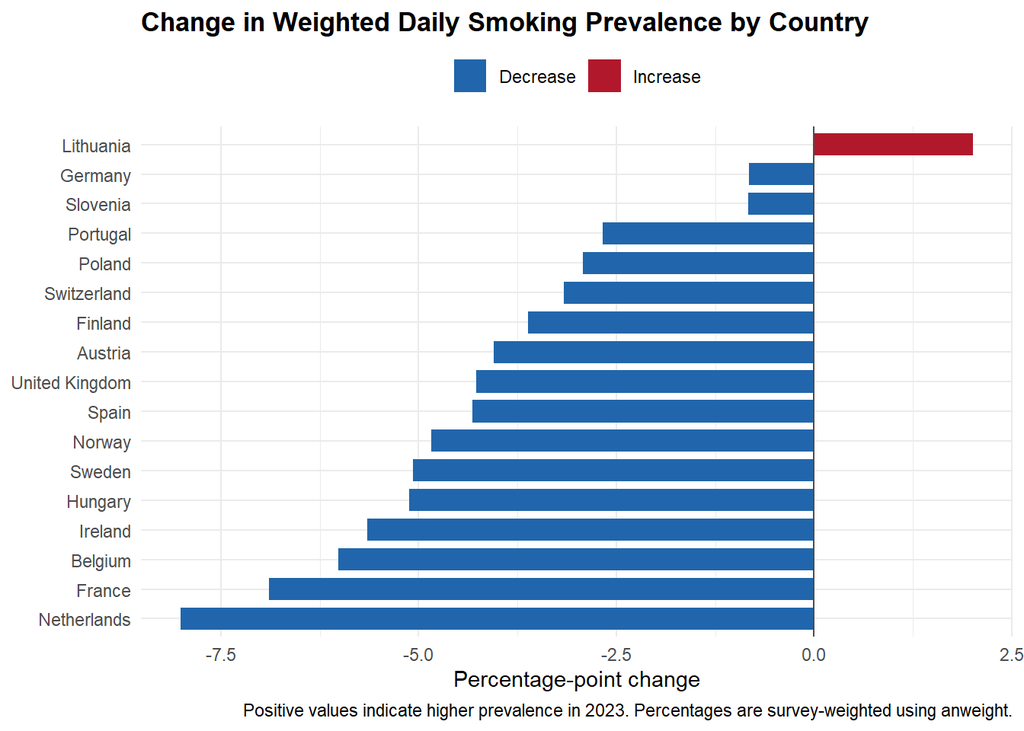

```r
daily_smoker_change <- ess_survey %>%
  group_by(country_name, survey_year) %>%
  summarise(
    unweighted_n = unweighted(dplyr::n()),
    weighted_pct = survey_mean(daily_smoker == "Yes", vartype = NULL, na.rm = TRUE) * 100,
    .groups = "drop"
  ) %>%
  mutate(
    survey_year = as.character(survey_year)
  ) %>%
  select(country_name, survey_year, weighted_pct) %>%
  pivot_wider(
    names_from = survey_year,
    values_from = weighted_pct
  ) %>%
  rename(
    weighted_pct_2014 = `2014`,
    weighted_pct_2023 = `2023`
  ) %>%
  mutate(
    change_2023_minus_2014 = weighted_pct_2023 - weighted_pct_2014,
    change_direction = case_when(
      change_2023_minus_2014 > 0 ~ "Increase",
      change_2023_minus_2014 < 0 ~ "Decrease",
      TRUE ~ "No change"
    ),
    change_direction = factor(
      change_direction,
      levels = c("Decrease", "No change", "Increase")
    )
  )

ggplot(
  daily_smoker_change,
  aes(
    x = reorder(country_name, change_2023_minus_2014),
    y = change_2023_minus_2014,
    fill = change_direction
  )
) +
  geom_col(width = 0.75) +
  geom_hline(yintercept = 0, linewidth = 0.4, color = "grey30") +
  coord_flip() +
  scale_fill_manual(
    values = c(
      "Decrease" = "#2166AC",
      "No change" = "grey60",
      "Increase" = "#B2182B"
    )
  ) +
  labs(
    title = "Change in Weighted Daily Smoking Prevalence by Country",
    x = NULL,
    y = "Percentage-point change",
    fill = NULL,
    caption = "Positive values indicate higher prevalence in 2023. Percentages are survey-weighted using anweight."
  ) +
  theme_minimal() +
  theme(
    plot.title = element_text(face = "bold"),
    legend.position = "top"
  )
```

If you want a compact country-level summary across both years:

This chunk checks whether each country has usable primary outcome data in both survey years.

```r
primary_outcome_availability <- ess_clean %>%
  group_by(country_name,  survey_year) %>%
  summarise(
    n_total = n(),
    n_non_missing = sum(!is.na(daily_smoker)),
    n_missing = sum(is.na(daily_smoker)),
    percent_missing = round(100 * n_missing / n_total, 1),
    n_daily_smokers = sum(daily_smoker == 1, na.rm = TRUE),
    n_non_daily_smokers = sum(daily_smoker == 0, na.rm = TRUE),
    outcome_status = case_when(
      n_non_missing == 0 ~ "No outcome data",
      n_daily_smokers == 0 ~ "No daily smokers",
      n_non_daily_smokers == 0 ~ "No non-daily smokers",
      percent_missing > 20 ~ "High missingness",
      TRUE ~ "Available"
    ),
    .groups = "drop"
  ) %>%
  arrange(country_name, survey_year)

primary_outcome_availability
```

```
## # A tibble: 34 × 9
##    country_name survey_year n_total n_non_missing n_missing percent_missing
##    <chr>        <fct>         <int>         <int>     <int>           <dbl>
##  1 Austria      2014           1628          1627         1             0.1
##  2 Austria      2023           2221          2220         1             0
##  3 Belgium      2014           1483          1482         1             0.1
##  4 Belgium      2023           1365          1364         1             0.1
##  5 Finland      2014           1861          1860         1             0.1
##  6 Finland      2023           1423          1422         1             0.1
##  7 France       2014           1711          1711         0             0
##  8 France       2023           1542          1540         2             0.1
##  9 Germany      2014           2691          2690         1             0
## 10 Germany      2023           2143          2142         1             0
## # ℹ 24 more rows
## # ℹ 3 more variables: n_daily_smokers <int>, n_non_daily_smokers <int>,
## #   outcome_status <chr>
```

```r
primary_outcome_country_summary <- primary_outcome_availability %>%
  group_by(country_name) %>%
  summarise(
    years_available = paste(sort(unique(survey_year[n_non_missing > 0])), collapse = ", "),
    n_years_available = n_distinct(survey_year[n_non_missing > 0]),
    total_n = sum(n_total),
    total_non_missing = sum(n_non_missing),
    total_missing = sum(n_missing),
    total_daily_smokers = sum(n_daily_smokers),
    total_non_daily_smokers = sum(n_non_daily_smokers),
    country_status = case_when(
      n_years_available < 2 ~ "Missing one survey year",
      total_non_missing == 0 ~ "No outcome data",
      total_daily_smokers == 0 ~ "No daily smokers",
      total_non_daily_smokers == 0 ~ "No non-daily smokers",
      TRUE ~ "Available in both years"
    ),
    .groups = "drop"
  ) %>%
  arrange(country_status, country_name)

primary_outcome_country_summary
```

```
## # A tibble: 17 × 9
##    country_name   years_available n_years_available total_n total_non_missing
##    <chr>          <chr>                       <int>   <int>             <int>
##  1 Austria        2014, 2023                      2    3849              3847
##  2 Belgium        2014, 2023                      2    2848              2846
##  3 Finland        2014, 2023                      2    3284              3282
##  4 France         2014, 2023                      2    3253              3251
##  5 Germany        2014, 2023                      2    4834              4832
##  6 Hungary        2014, 2023                      2    3389              3372
##  7 Ireland        2014, 2023                      2    4042              4029
##  8 Lithuania      2014, 2023                      2    3218              3209
##  9 Netherlands    2014, 2023                      2    3230              3228
## 10 Norway         2014, 2023                      2    2363              2361
## 11 Poland         2014, 2023                      2    2614              2611
## 12 Portugal       2014, 2023                      2    2446              2443
## 13 Slovenia       2014, 2023                      2    2146              2144
## 14 Spain          2014, 2023                      2    3320              3318
## 15 Sweden         2014, 2023                      2    2688              2684
## 16 Switzerland    2014, 2023                      2    2530              2527
## 17 United Kingdom 2014, 2023                      2    3634              3632
## # ℹ 4 more variables: total_missing <int>, total_daily_smokers <int>,
## #   total_non_daily_smokers <int>, country_status <chr>
```

```r
primary_outcome_country_summary %>%
  select(
    country_name,
    years_available,
    total_n,
    total_non_missing,
    total_missing
  ) %>%
  gt(rowname_col = "country_name") %>%
  tab_header(
    title = md("**Primary Outcome Availability by Country**"),
    subtitle = md("*Daily smoking outcome, 2014 and 2023*")
  ) %>%
  cols_label(
    years_available = "Years available",
    total_n = "Total n",
    total_non_missing = "Non-missing n",
    total_missing = "Missing n"
  ) %>%
  fmt_number(
    columns = c(total_n, total_non_missing, total_missing),
    decimals = 0,
    use_seps = TRUE
  ) %>%
  cols_align(
    align = "right",
    columns = c(total_n, total_non_missing, total_missing)
  ) %>%
  cols_align(
    align = "left",
    columns = years_available
  ) %>%
  tab_stubhead(label = md("**Country**")) %>%
  tab_options(
    table.width = pct(100),
    table.font.size = px(13),
    heading.title.font.size = px(16),
    column_labels.font.weight = "bold",
    data_row.padding = px(3),
    table.border.top.style = "solid",
    table.border.bottom.style = "solid"
  ) %>%
  tab_source_note(
    md("*Availability was assessed using unweighted counts. The primary outcome was daily smoking.*")
  )
```

**Primary Outcome Availability by Country**

*Daily smoking outcome, 2014 and 2023*

| **Country** | Years available | Total n | Non-missing n | Missing n |
| --- | --- | --- | --- | --- |
| Austria | 2014, 2023 | 3,849 | 3,847 | 2 |
| Belgium | 2014, 2023 | 2,848 | 2,846 | 2 |
| Finland | 2014, 2023 | 3,284 | 3,282 | 2 |
| France | 2014, 2023 | 3,253 | 3,251 | 2 |
| Germany | 2014, 2023 | 4,834 | 4,832 | 2 |
| Hungary | 2014, 2023 | 3,389 | 3,372 | 17 |
| Ireland | 2014, 2023 | 4,042 | 4,029 | 13 |
| Lithuania | 2014, 2023 | 3,218 | 3,209 | 9 |
| Netherlands | 2014, 2023 | 3,230 | 3,228 | 2 |
| Norway | 2014, 2023 | 2,363 | 2,361 | 2 |
| Poland | 2014, 2023 | 2,614 | 2,611 | 3 |
| Portugal | 2014, 2023 | 2,446 | 2,443 | 3 |
| Slovenia | 2014, 2023 | 2,146 | 2,144 | 2 |
| Spain | 2014, 2023 | 3,320 | 3,318 | 2 |
| Sweden | 2014, 2023 | 2,688 | 2,684 | 4 |
| Switzerland | 2014, 2023 | 2,530 | 2,527 | 3 |
| United Kingdom | 2014, 2023 | 3,634 | 3,632 | 2 |

*Availability was assessed using unweighted counts. The primary outcome was daily smoking.*

## Primary Exposure Availability by Country

This chunk checks availability of the two primary SES exposures, education and household income, by country and survey year. Income availability is based on observed income group, before missing income is converted into a separate category.

```r
primary_exposure_availability <- ess_clean %>%
  group_by(country_name, cntry, survey_year) %>%
  summarise(
    n_total = n(),

    n_education_non_missing = sum(!is.na(education)),
    n_education_missing = sum(is.na(education)),

    n_income_non_missing = sum(!is.na(income_group)),
    n_income_missing = sum(is.na(income_group)),

    pct_education_missing = round(100 * n_education_missing / n_total, 1),
    pct_income_missing = round(100 * n_income_missing / n_total, 1),

    .groups = "drop"
  ) %>%
  arrange(country_name, survey_year)

primary_exposure_availability
```

```
## # A tibble: 34 × 10
##    country_name cntry survey_year n_total n_education_non_missing
##    <chr>        <chr> <fct>         <int>                   <int>
##  1 Austria      AT    2014           1628                    1625
##  2 Austria      AT    2023           2221                    2200
##  3 Belgium      BE    2014           1483                    1475
##  4 Belgium      BE    2023           1365                    1343
##  5 Finland      FI    2014           1861                    1858
##  6 Finland      FI    2023           1423                    1421
##  7 France       FR    2014           1711                    1706
##  8 France       FR    2023           1542                    1535
##  9 Germany      DE    2014           2691                    2690
## 10 Germany      DE    2023           2143                    2135
## # ℹ 24 more rows
## # ℹ 5 more variables: n_education_missing <int>, n_income_non_missing <int>,
## #   n_income_missing <int>, pct_education_missing <dbl>,
## #   pct_income_missing <dbl>
```

This chunk summarises education and income availability across both survey years for each country.

```r
primary_exposure_country_summary <- primary_exposure_availability %>%
  group_by(country_name, cntry) %>%
  summarise(
    years_available = paste(sort(unique(survey_year)), collapse = ", "),
    total_n = sum(n_total),

    education_non_missing = sum(n_education_non_missing),
    education_missing = sum(n_education_missing),
    education_pct_missing = round(100 * education_missing / total_n, 1),

    income_non_missing = sum(n_income_non_missing),
    income_missing = sum(n_income_missing),
    income_pct_missing = round(100 * income_missing / total_n, 1),

    .groups = "drop"
  ) %>%
  arrange(country_name)

primary_exposure_country_summary
```

```
## # A tibble: 17 × 10
##    country_name   cntry years_available total_n education_non_missing
##    <chr>          <chr> <chr>             <int>                 <int>
##  1 Austria        AT    2014, 2023         3849                  3825
##  2 Belgium        BE    2014, 2023         2848                  2818
##  3 Finland        FI    2014, 2023         3284                  3279
##  4 France         FR    2014, 2023         3253                  3241
##  5 Germany        DE    2014, 2023         4834                  4825
##  6 Hungary        HU    2014, 2023         3389                  3382
##  7 Ireland        IE    2014, 2023         4042                  4004
##  8 Lithuania      LT    2014, 2023         3218                  3205
##  9 Netherlands    NL    2014, 2023         3230                  3208
## 10 Norway         NO    2014, 2023         2363                  2356
## 11 Poland         PL    2014, 2023         2614                  2611
## 12 Portugal       PT    2014, 2023         2446                  2444
## 13 Slovenia       SI    2014, 2023         2146                  2137
## 14 Spain          ES    2014, 2023         3320                  3312
## 15 Sweden         SE    2014, 2023         2688                  2662
## 16 Switzerland    CH    2014, 2023         2530                  2524
## 17 United Kingdom GB    2014, 2023         3634                  3534
## # ℹ 5 more variables: education_missing <int>, education_pct_missing <dbl>,
## #   income_non_missing <int>, income_missing <int>, income_pct_missing <dbl>
```

```r
primary_exposure_country_summary %>%
  select(
    country_name,
    years_available,
    total_n,
    education_non_missing,
    education_missing,
    education_pct_missing,
    income_non_missing,
    income_missing,
    income_pct_missing
  ) %>%
  gt(rowname_col = "country_name") %>%
  tab_header(
    title = md("**Primary Exposure Availability by Country**"),
    subtitle = md("*Education and household income, 2014 and 2023*")
  ) %>%
  tab_spanner(
    label = "Education",
    columns = c(education_non_missing, education_missing, education_pct_missing)
  ) %>%
  tab_spanner(
    label = "Household income",
    columns = c(income_non_missing, income_missing, income_pct_missing)
  ) %>%
  cols_label(
    years_available = "Years available",
    total_n = "Total n",
    education_non_missing = "Non-missing n",
    education_missing = "Missing n",
    education_pct_missing = "Missing %",
    income_non_missing = "Non-missing n",
    income_missing = "Missing n",
    income_pct_missing = "Missing %"
  ) %>%
  fmt_number(
    columns = c(
      total_n,
      education_non_missing,
      education_missing,
      income_non_missing,
      income_missing
    ),
    decimals = 0,
    use_seps = TRUE
  ) %>%
  fmt_number(
    columns = c(education_pct_missing, income_pct_missing),
    decimals = 1
  ) %>%
  cols_align(
    align = "right",
    columns = c(
      total_n,
      education_non_missing,
      education_missing,
      education_pct_missing,
      income_non_missing,
      income_missing,
      income_pct_missing
    )
  ) %>%
  cols_align(
    align = "left",
    columns = years_available
  ) %>%
  tab_stubhead(label = md("**Country**")) %>%
  tab_options(
    table.width = pct(100),
    table.font.size = px(13),
    heading.title.font.size = px(16),
    column_labels.font.weight = "bold",
    data_row.padding = px(3),
    table.border.top.style = "solid",
    table.border.bottom.style = "solid"
  ) %>%
  tab_source_note(
    md("*Availability was assessed using unweighted counts. Household income availability is based on observed income before assigning a missing-income category.*")
  )
```

**Primary Exposure Availability by Country**

*Education and household income, 2014 and 2023*

| **Country** | Years available | Total n | Education Non-missing n | Education Missing n | Education Missing % | Household income Non-missing n | Household income Missing n | Household income Missing % |
| --- | --- | --- | --- | --- | --- | --- | --- | --- |
| Austria | 2014, 2023 | 3,849 | 3,825 | 24 | 0.6 | 3,008 | 841 | 21.8 |
| Belgium | 2014, 2023 | 2,848 | 2,818 | 30 | 1.1 | 2,690 | 158 | 5.5 |
| Finland | 2014, 2023 | 3,284 | 3,279 | 5 | 0.2 | 3,145 | 139 | 4.2 |
| France | 2014, 2023 | 3,253 | 3,241 | 12 | 0.4 | 3,031 | 222 | 6.8 |
| Germany | 2014, 2023 | 4,834 | 4,825 | 9 | 0.2 | 4,443 | 391 | 8.1 |
| Hungary | 2014, 2023 | 3,389 | 3,382 | 7 | 0.2 | 2,580 | 809 | 23.9 |
| Ireland | 2014, 2023 | 4,042 | 4,004 | 38 | 0.9 | 3,271 | 771 | 19.1 |
| Lithuania | 2014, 2023 | 3,218 | 3,205 | 13 | 0.4 | 2,766 | 452 | 14.0 |
| Netherlands | 2014, 2023 | 3,230 | 3,208 | 22 | 0.7 | 2,979 | 251 | 7.8 |
| Norway | 2014, 2023 | 2,363 | 2,356 | 7 | 0.3 | 2,293 | 70 | 3.0 |
| Poland | 2014, 2023 | 2,614 | 2,611 | 3 | 0.1 | 1,978 | 636 | 24.3 |
| Portugal | 2014, 2023 | 2,446 | 2,444 | 2 | 0.1 | 1,974 | 472 | 19.3 |
| Slovenia | 2014, 2023 | 2,146 | 2,137 | 9 | 0.4 | 1,844 | 302 | 14.1 |
| Spain | 2014, 2023 | 3,320 | 3,312 | 8 | 0.2 | 2,775 | 545 | 16.4 |
| Sweden | 2014, 2023 | 2,688 | 2,662 | 26 | 1.0 | 2,570 | 118 | 4.4 |
| Switzerland | 2014, 2023 | 2,530 | 2,524 | 6 | 0.2 | 2,236 | 294 | 11.6 |
| United Kingdom | 2014, 2023 | 3,634 | 3,534 | 100 | 2.8 | 2,944 | 690 | 19.0 |

*Availability was assessed using unweighted counts. Household income availability is based on observed income before assigning a missing-income category.*

Since education and income models should use comparable samples, this chunk checks how many respondents are available for the main model.

```r
ess_clean %>%
  summarise(
    n_total = n(),
    n_model_sample = sum(
      !is.na(daily_smoker) &
      !is.na(education) &
      !is.na(income_group_missing) &
      !is.na(agea) &
      !is.na(sex) &
      !is.na(survey_year) &
      !is.na(country_name)
    ),
    pct_model_sample = round(100 * n_model_sample / n_total, 1)
  )
```

```
## # A tibble: 1 × 3
##   n_total n_model_sample pct_model_sample
##     <int>          <int>            <dbl>
## 1   53688          53305             99.3
```

```r
levels(ess_clean$education)
```

```
## [1] "Low"    "Medium" "High"
```

```r
levels(ess_clean$income_group_missing)
```

```
## [1] "Low"            "Middle"         "High"           "Missing income"
```

```r
levels(ess_clean$sex)
```

```
## [1] "Male"   "Female"
```

```r
levels(ess_clean$survey_year)
```

```
## [1] "2014" "2023"
```